# Practice

2015-11-13

An article in the *Journal of Statistics Education* reported the price of diamonds of different sizes in Singapore dollars (SGD). The following data frame (`DF`) contains a data set that is consistent with this data, adjusted to US dollars in 2004:

```r
USdollars <- c(494.82, 768.03, 1105.03, 1508.88, 1826.18, 2096.89, 688.24, 944.90, 1071.75, 1504.44, 1908.28, 2409.76, 748.10, 1076.18, 1289.20, 1597.63, 2038.09)
Carat <- c(0.12, 0.17, 0.20, 0.25, 0.28, 0.33, 0.15, 0.18, 0.21, 0.26, 0.29, 0.35, 0.16, 0.19, 0.23, 0.27, 0.32)
DF <- data.frame(USdollars = USdollars, Carat = Carat)
rm("Carat", "USdollars")
head(DF)
```

```
##   USdollars Carat
## 1    494.82  0.12
## 2    768.03  0.17
## 3   1105.03  0.20
## 4   1508.88  0.25
## 5   1826.18  0.28
## 6   2096.89  0.33
```

```r
mod <- lm(USdollars ~ Carat, data = DF)
summary(mod)
```

```
##
## Call:
## lm(formula = USdollars ~ Carat, data = DF)
##
## Residuals:
##    Min     1Q Median     3Q    Max
## -96.99 -58.86  11.13  66.33  89.51
##
## Coefficients:
##             Estimate Std. Error t value Pr(>|t|)
## (Intercept)  -558.52      57.88  -9.649 7.98e-08 ***
## Carat        8225.06     239.11  34.399 1.10e-15 ***
## ---
## Signif. codes:  0 '***' 0.001 '**' 0.01 '*' 0.05 '.' 0.1 ' ' 1
##
## Residual standard error: 64.94 on 15 degrees of freedom
## Multiple R-squared:  0.9875, Adjusted R-squared:  0.9866
## F-statistic:  1183 on 1 and 15 DF,  p-value: 1.098e-15
```

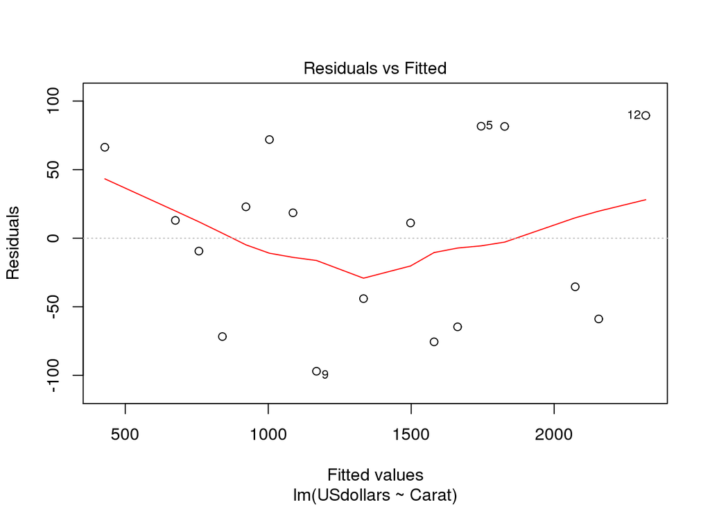

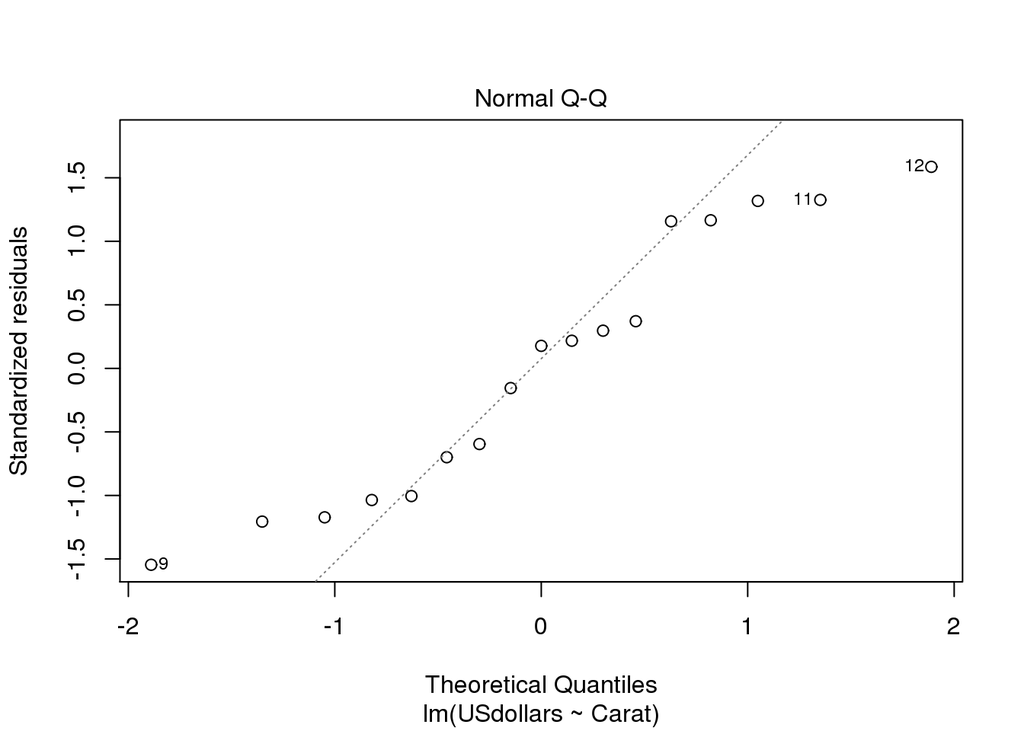

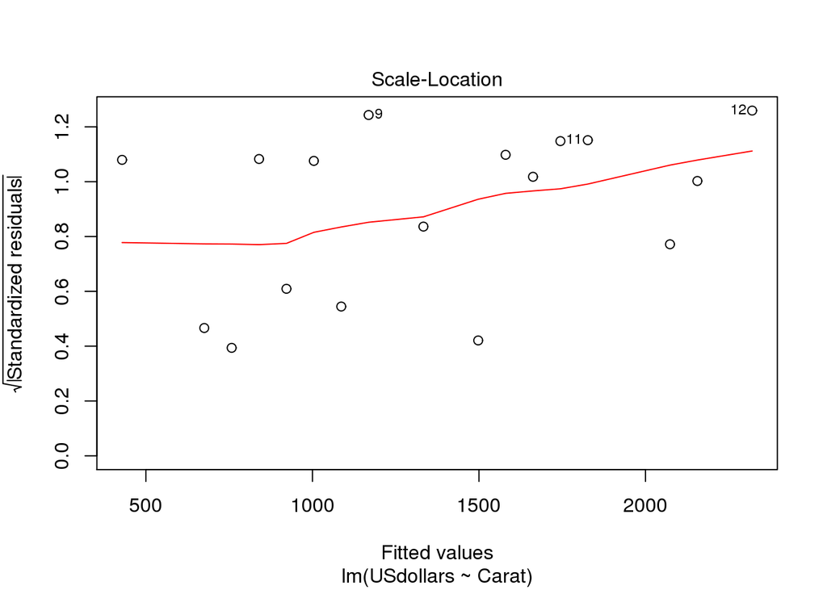

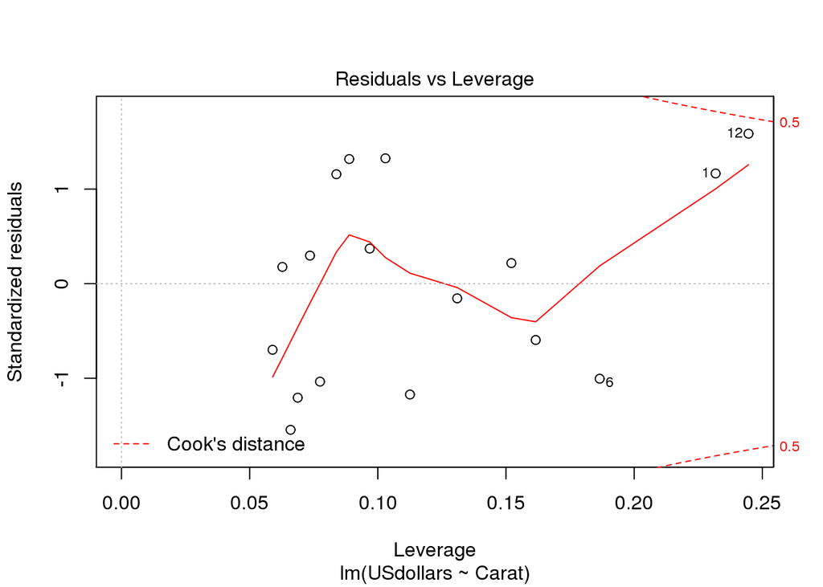

```r
plot(mod)
```

Goes up by 8,000 dollars, that is what this is predicting 1. Make a scatterplot and describe the association between the size of the diamond (carat) and the cost (in US dollars).

For each unit that increases in carat size the price goes up by $8225.06

5. Interpret the intercept of your model in context.

6. What is the correlation between cost and size?

7. Explain the meaning of $R^2$ in the context of this problem. It means the residuals multiplied are squared.
8. Would it be better for a customer buying a diamond to have a negative residual or a positive residual from this model? Explain. observed - predicted

Negative residual because you spend less.

Of the 23 first year male students at State U. admitted for Jim Thorpe High School, 8 were offered baseball scholarships and 7 were offered football scholarships. The University admissions committee looked at the students’ composite ACT scores wondering if the University was lowering their standards for athletes. Assuming that this group of students is representative of all admitted students, what do you think?

```r
Baseball <- c(25, 22, 19, 25, 24, 25, 24, 23)
NonAthletes <- c(21, 27, 29, 26, 30, 27, 26, 23)
Football <- c(22, 21, 24, 27, 19, 23, 17, NA)
DF2 <- stack(data.frame(Baseball, NonAthletes, Football))
colnames(DF2) <- list("ACT", "Sport")
head(DF2)
```

```
##   ACT    Sport
## 1  25 Baseball
## 2  22 Baseball
## 3  19 Baseball
## 4  25 Baseball
## 5  24 Baseball
## 6  25 Baseball
```

```r
mod <- aov(ACT~Sport, data=DF2)
summary(mod)
```

```
##             Df Sum Sq Mean Sq F value Pr(>F)
## Sport        2   71.0   35.50   4.563 0.0233 *
## Residuals   20  155.6    7.78
## ---
## Signif. codes:  0 '***' 0.001 '**' 0.01 '*' 0.05 '.' 0.1 ' ' 1
## 1 observation deleted due to missingness
```

```r
TukeyHSD(mod)
```

```
##   Tukey multiple comparisons of means
##     95% family-wise confidence level
##
## Fit: aov(formula = ACT ~ Sport, data = DF2)
##
## $Sport
##                           diff        lwr      upr     p adj
## Football-Baseball    -1.517857 -5.1701768 2.134463 0.5541765
## NonAthletes-Baseball  2.750000 -0.7784760 6.278476 0.1452038
## NonAthletes-Football  4.267857  0.6155375 7.920177 0.0204005
```

1. Test an appropriate hypothesis and state your conclusion. Specify the null and alternative hypotheses with both mathematical symbols and with a verbal (English) description.

2. Are the two sports teams mean ACT scores different?

No, the mean scores for football players and baseball players is not significantly different.

Use the data frame `Snore` from the `BSDA` package to determine if snoring and heart-disease are related.

```r
library(BSDA)
head(Snore)
```

```
##   heart  Non occasion nearly every
## 1   yes   24       35     21    30
## 2    no 1355      603    192   224
```

```r
Snore[,2:5]
```

```
##    Non occasion nearly every
## 1   24       35     21    30
## 2 1355      603    192   224
```

```r
chisq.test(Snore[, 2:5])
```

```
##
##  Pearson's Chi-squared test
##
## data:  Snore[, 2:5]
## X-squared = 72.782, df = 3, p-value = 1.082e-15
```

1. Write the null and alternative hypotheses.

Null Hypothesis: heart condition and snoring are independent. Alternative Hypothesis: heart condition and snoring are dependent.

2. Test your null hypothesis and state your conclusion?  
   Reject, the null hypothesis because the variables are dependent, which is supported by the p value (1.082e-15) that is determined by the chi square test. Therefore the data supports the alternative hypothesis.
3. Do you need to run any post-hoc tests? If so, how many post-hoc tests do you need to examine? If indicated, perform the post-hoc tests and interpret your findings. Yes, run a chi square test (found above). Which determines that the variables are dependent.